# FinalRecruitment_Results

Hannah Merges

2024-08-19

## Create dataframe that summarize all recruit counts JUST for Poc

- use this df for analysis bc ONLY looking at poc recruits

```r
RecruitmentCounts_Poconly <- RecruitmentCounts %>%
  group_by(CowTagID, Location) %>%
  dplyr::summarise(sum_total = sum(Pocilloporidae),
            sum_total_dead = sum(Dead),
            sum_total_alive=sum(sum_total-sum_total_dead))
```

### Look at the diversity of non-Poc recruits on the tiles

```r
nonPoc_recruits <- RecruitmentCounts %>%
  group_by(CowTagID, Location) %>%
  dplyr::summarise(total_Por = sum(Poritidae),
                   total_Acrop = sum(Acroporidae),
                   sum_total_nonPoc = sum(Poritidae+Acroporidae+Other))
nonPoc_recruits_bysite <- nonPoc_recruits %>%
  group_by(Location) %>%
  dplyr::summarise(totalPor = sum(total_Por),
                   totalAcrop = sum(total_Acrop),
                   totalnonPoc = sum(sum_total_nonPoc))
```

## Figure 1: Poc Cover Data

Plot: percent cover on the x, total recruit counts on the y, faceted by location - shown on same plot to show differences between sites, however could also separate onto different plots

- Note: as of August 16th, 2024 - confirmed that missing P. acuta data for some CowTagIDs should be equal to 0
- finding: reference the Poc_Cover_Data script for the tidying and creation of df

Stats: - run model comparison between linear and nonlinear

**Results**: SEE POC_COVER_DATA MARKDOWN FOR RESULTS AND MODELS

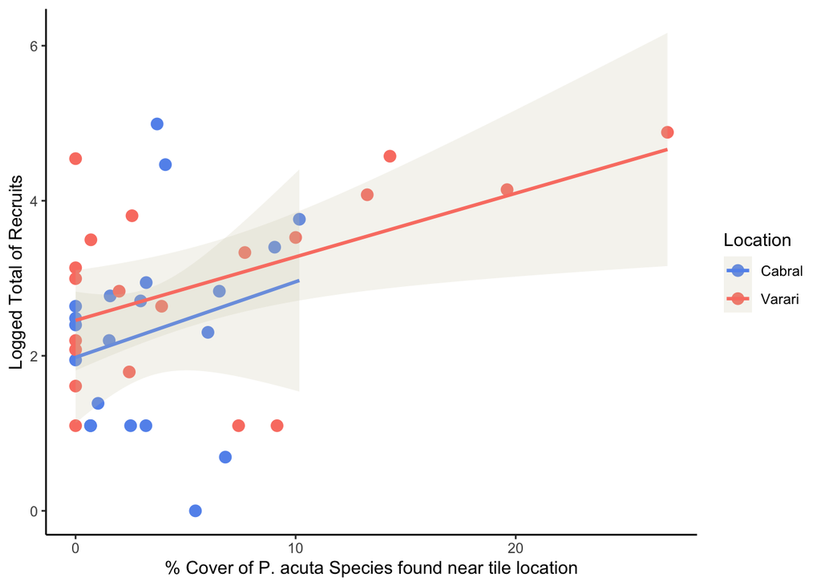

```r
recruits_by_PocCover <- EnvData_wPocCover %>%
  ggplot(aes(x=percent_cover,
             y=log(sum_total+1),
             color=Location)) +
  geom_point(size=3) +
  theme_classic() +
  scale_color_manual(values=c("cornflowerblue", "salmon")) +
  geom_smooth(method=lm,
              fill="cornsilk3",
              alpha=0.2) + ## alpha adjusts the transparency
  labs(x="% Cover of P. acuta Species found near tile location",
       y="Logged Total of Recruits")

recruits_by_PocCover
```

```r
ggsave(here::here("Outputs", "RecruitmentTiles", "Results", "Prelim", "recruits_by_PocCover.jpg"))
### run models here
```

### Silicate with recruit data

Plot: average silicate concentrations on the x, *logged* total recruit counts on the y, faceted by location - shown on same plot to show differences between sites, however could also separate onto different plots

Stats: - run model comparison between linear and nonlinear - model:

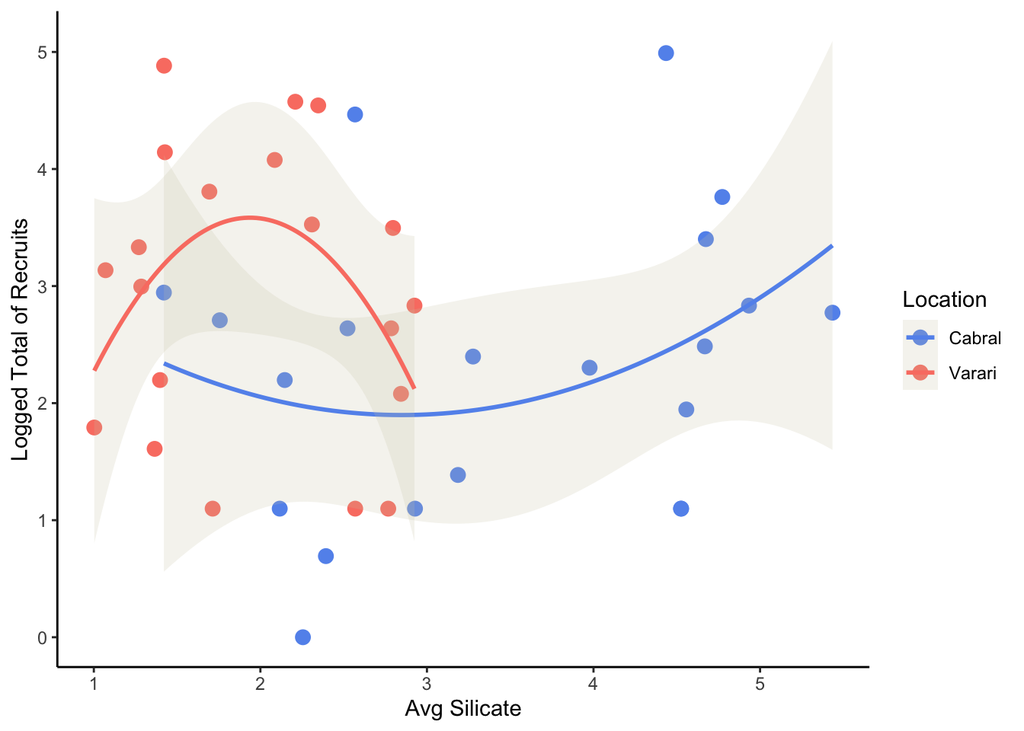

```r
###############################
## plot
###############################
recruits_by_silicate <- EnvData_wPocCover %>%
  ggplot(aes(x=silicate_avg,
             y=log(sum_total+1),
             color=Location)) +
  geom_point(size=3) +
  theme_classic() +
  scale_color_manual(values=c("cornflowerblue", "salmon")) +
  geom_smooth(method=lm,
              formula="y~poly(x,2)",
              fill="cornsilk3",
              alpha=0.2) + ## alpha adjusts the transparency
  labs(x="Avg Silicate",
       y="Logged Total of Recruits")

recruits_by_silicate
```

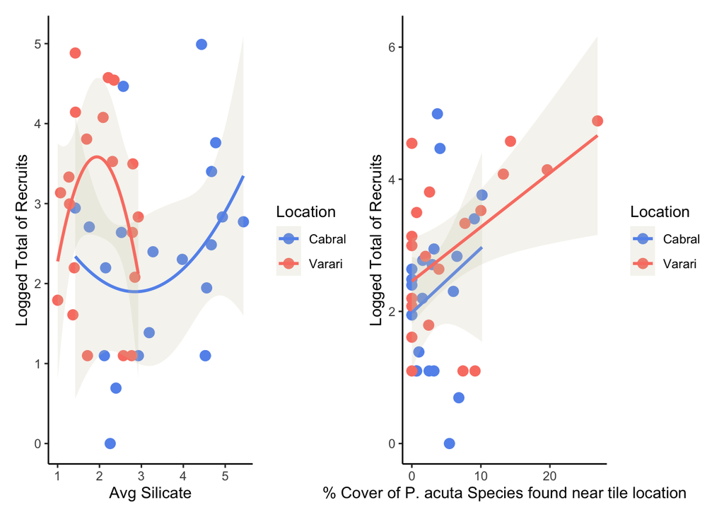

```r
#################
## join two plots together (silicate data and Poc cover data) into same plot
recruits_by_silicate + recruits_by_PocCover
```

```r
ggsave(here::here("Outputs", "RecruitmentTiles", "Results", "Prelim", "PocCoverANDSilicate.jpg"),
       width=10, height=7)
###############################
## Statistics
###############################

##### linear model
silicate_recruit_model <- lm(log(sum_total+1) ~ silicate_avg*Location, data=EnvData_wPocCover)

anova(silicate_recruit_model)
```

```
## Analysis of Variance Table
##
## Response: log(sum_total + 1)
##                       Df Sum Sq Mean Sq F value  Pr(>F)
## silicate_avg           1  0.236  0.2355  0.1530 0.69789
## Location               1  5.038  5.0381  3.2739 0.07852 .
## silicate_avg:Location  1  1.233  1.2326  0.8010 0.37659
## Residuals             37 56.938  1.5389
## ---
## Signif. codes:  0 '***' 0.001 '**' 0.01 '*' 0.05 '.' 0.1 ' ' 1
```

```r
summary(silicate_recruit_model)
```

```
##
## Call:
## lm(formula = log(sum_total + 1) ~ silicate_avg * Location, data = EnvData_wPocCover)
##
## Residuals:
##      Min       1Q   Median       3Q      Max
## -1.99254 -0.85884  0.02754  0.81023  2.44885
##
## Coefficients:
##                             Estimate Std. Error t value Pr(>|t|)
## (Intercept)                   1.4246     0.8252   1.726   0.0926 .
## silicate_avg                  0.2518     0.2240   1.124   0.2682
## LocationVarari                1.8748     1.2074   1.553   0.1290
## silicate_avg:LocationVarari  -0.4307     0.4812  -0.895   0.3766
## ---
## Signif. codes:  0 '***' 0.001 '**' 0.01 '*' 0.05 '.' 0.1 ' ' 1
##
## Residual standard error: 1.241 on 37 degrees of freedom
## Multiple R-squared:  0.1025, Adjusted R-squared:  0.02978
## F-statistic: 1.409 on 3 and 37 DF,  p-value: 0.2555
```

```r
##### nonlinear model

silicate_recruit_model_nonlin <- lm(log(sum_total+1) ~ poly(silicate_avg,2)*Location, data=EnvData_wPocCover)

anova(silicate_recruit_model_nonlin)
```

```
## Analysis of Variance Table
##
## Response: log(sum_total + 1)
##                                Df Sum Sq Mean Sq F value  Pr(>F)
## poly(silicate_avg, 2)           2  1.978  0.9889  0.6654 0.52044
## Location                        1  4.773  4.7731  3.2119 0.08175 .
## poly(silicate_avg, 2):Location  2  4.681  2.3404  1.5749 0.22135
## Residuals                      35 52.013  1.4861
## ---
## Signif. codes:  0 '***' 0.001 '**' 0.01 '*' 0.05 '.' 0.1 ' ' 1
```

```r
summary(silicate_recruit_model_nonlin)
```

```
##
## Call:
## lm(formula = log(sum_total + 1) ~ poly(silicate_avg, 2) * Location,
##     data = EnvData_wPocCover)
##
## Residuals:
##     Min      1Q  Median      3Q     Max
## -2.4107 -0.8010  0.1316  0.7109  2.5507
##
## Coefficients:
##                                       Estimate Std. Error t value Pr(>|t|)
## (Intercept)                             2.2318     0.3395   6.574 1.36e-07 ***
## poly(silicate_avg, 2)1                  0.8581     2.1747   0.395   0.6956
## poly(silicate_avg, 2)2                  1.9441     2.2266   0.873   0.3886
## LocationVarari                         -1.9032     1.6450  -1.157   0.2551
## poly(silicate_avg, 2)1:LocationVarari -28.3903    16.8214  -1.688   0.1004
## poly(silicate_avg, 2)2:LocationVarari -15.3852     8.7033  -1.768   0.0858 .
## ---
## Signif. codes:  0 '***' 0.001 '**' 0.01 '*' 0.05 '.' 0.1 ' ' 1
##
## Residual standard error: 1.219 on 35 degrees of freedom
## Multiple R-squared:  0.1802, Adjusted R-squared:  0.06307
## F-statistic: 1.538 on 5 and 35 DF,  p-value: 0.2033
```

### Compare Poc cover vs Silicate to see if there is a relationship

Stats: ran two separate models (bc sites are so different) - important note: there is missing percent cover data for some of the rebar/cowtags

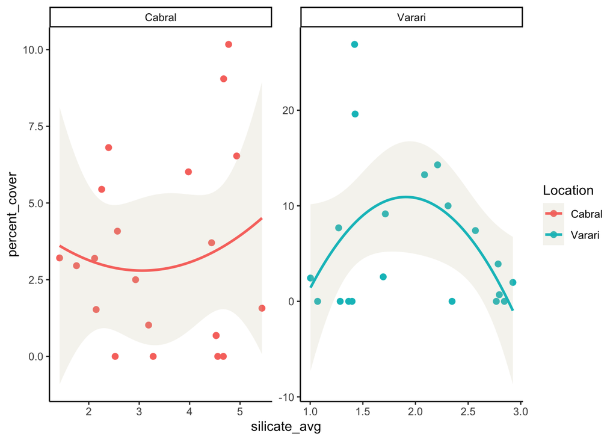

```r
#######################
## plot
######################

##### plot by site
PocCover_vs_Silicate <- EnvData_wPocCover %>%
  ggplot(aes(x=silicate_avg,
             y=percent_cover,
             color=Location)) +
  geom_point(size=2) +
  theme_classic() +
  facet_wrap(~Location, scales="free") +
  geom_smooth(method=lm,
              formula="y~poly(x,2)",
              fill="cornsilk3",
              alpha=0.2) ## alpha adjusts the transparency

PocCover_vs_Silicate
```

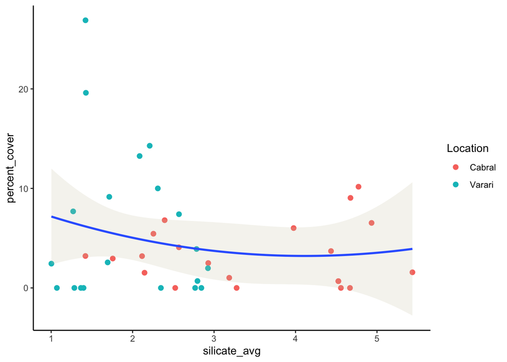

```r
ggsave(here::here("Outputs", "RecruitmentTiles", "Results", "Prelim", "silicate_by_PocCover.jpg"),
       width=10, height=7)

############
## try plotting just as one site and with one geom_smooth

PocCover_vs_Silicate2 <- EnvData_wPocCover %>%
  ggplot(aes(x=silicate_avg,
             y=percent_cover)) +
  geom_point(size=2, aes(color=Location)) +
  theme_classic() +
 # facet_wrap(~Location, scales="free") +
  geom_smooth(method=lm,
              formula="y~poly(x,2)",
              fill="cornsilk3",
              alpha=0.2) ## alpha adjusts the transparency

PocCover_vs_Silicate2
```

```r
ggsave(here::here("Outputs", "RecruitmentTiles", "Results", "Prelim", "silicate_by_PocCover.jpg"),
       width=10, height=7)
```

- run models (run sites separately and try a multiple regresssion )

```r
## Varari
PocCover_vs_Silicate_Mregression_V <- lm(log(sum_total+1) ~ poly(silicate_avg, 2) + poly(percent_cover,2), data=EnvData_wPocCover %>%
                                   filter(Location=="Varari") %>%
                                   drop_na(percent_cover))

anova(PocCover_vs_Silicate_Mregression_V)
```

```
## Analysis of Variance Table
##
## Response: log(sum_total + 1)
##                        Df  Sum Sq Mean Sq F value Pr(>F)
## poly(silicate_avg, 2)   2  4.0640  2.0320  1.6506 0.2250
## poly(percent_cover, 2)  2  5.4822  2.7411  2.2266 0.1423
## Residuals              15 18.4663  1.2311
```

```r
summary(PocCover_vs_Silicate_Mregression_V)
```

```
##
## Call:
## lm(formula = log(sum_total + 1) ~ poly(silicate_avg, 2) + poly(percent_cover,
##     2), data = EnvData_wPocCover %>% filter(Location == "Varari") %>%
##     drop_na(percent_cover))
##
## Residuals:
##     Min      1Q  Median      3Q     Max
## -2.0512 -0.4486  0.3015  0.7475  1.4325
##
## Coefficients:
##                         Estimate Std. Error t value Pr(>|t|)
## (Intercept)              2.94802    0.24810  11.882 4.95e-09 ***
## poly(silicate_avg, 2)1   0.07892    1.14589   0.069    0.946
## poly(silicate_avg, 2)2  -1.43305    1.33553  -1.073    0.300
## poly(percent_cover, 2)1  2.08329    1.28261   1.624    0.125
## poly(percent_cover, 2)2  1.32913    1.20483   1.103    0.287
## ---
## Signif. codes:  0 '***' 0.001 '**' 0.01 '*' 0.05 '.' 0.1 ' ' 1
##
## Residual standard error: 1.11 on 15 degrees of freedom
## Multiple R-squared:  0.3408, Adjusted R-squared:  0.165
## F-statistic: 1.939 on 4 and 15 DF,  p-value: 0.1562
```

```r
## Cabral
PocCover_vs_Silicate_Mregression_C <- lm(log(sum_total+1) ~ poly(silicate_avg, 2) + poly(percent_cover,2), data=EnvData_wPocCover %>%
                                   filter(Location=="Cabral") %>%
                                   drop_na(percent_cover))

anova(PocCover_vs_Silicate_Mregression_C)
```

```
## Analysis of Variance Table
##
## Response: log(sum_total + 1)
##                        Df  Sum Sq Mean Sq F value Pr(>F)
## poly(silicate_avg, 2)   2  3.0776 1.53878  0.9167 0.4199
## poly(percent_cover, 2)  2  1.2053 0.60264  0.3590 0.7039
## Residuals              16 26.8588 1.67867
```

```r
summary(PocCover_vs_Silicate_Mregression_C)
```

```
##
## Call:
## lm(formula = log(sum_total + 1) ~ poly(silicate_avg, 2) + poly(percent_cover,
##     2), data = EnvData_wPocCover %>% filter(Location == "Cabral") %>%
##     drop_na(percent_cover))
##
## Residuals:
##      Min       1Q   Median       3Q      Max
## -2.16113 -0.76026 -0.08294  0.58043  2.55658
##
## Coefficients:
##                         Estimate Std. Error t value Pr(>|t|)
## (Intercept)               2.3009     0.2827   8.138 4.44e-07 ***
## poly(silicate_avg, 2)1    1.2382     1.4937   0.829    0.419
## poly(silicate_avg, 2)2    0.9603     1.3226   0.726    0.478
## poly(percent_cover, 2)1   1.1081     1.3098   0.846    0.410
## poly(percent_cover, 2)2   0.1123     1.5050   0.075    0.941
## ---
## Signif. codes:  0 '***' 0.001 '**' 0.01 '*' 0.05 '.' 0.1 ' ' 1
##
## Residual standard error: 1.296 on 16 degrees of freedom
## Multiple R-squared:  0.1375, Adjusted R-squared:  -0.07809
## F-statistic: 0.6378 on 4 and 16 DF,  p-value: 0.643
```

```r
################
### something is still going on with poly function so manually add percent cover squared column
## basic regression

EnvData_wPocCover2 <- EnvData_wPocCover %>%
  mutate(percent_cover2 = percent_cover^2)

### for Varari

### manual polyx,2
PocCover_vs_Silicate_model_V <- lm(silicate_avg~ percent_cover + percent_cover2, data=EnvData_wPocCover2 %>%
                                   filter(Location=="Varari") %>%
                                   drop_na(percent_cover))


### trouble with poly(x,2)
PocCover_vs_Silicate_model_V <- lm(silicate_avg~ poly(percent_cover,2), data=EnvData_wPocCover %>%
                                   filter(Location=="Varari") %>%
                                     drop_na(percent_cover))

anova(PocCover_vs_Silicate_model_V)
```

```
## Analysis of Variance Table
##
## Response: silicate_avg
##                        Df Sum Sq Mean Sq F value Pr(>F)
## poly(percent_cover, 2)  2 0.5226 0.26131  0.5581 0.5824
## Residuals              17 7.9599 0.46823
```

```r
summary(PocCover_vs_Silicate_model_V)
```

```
##
## Call:
## lm(formula = silicate_avg ~ poly(percent_cover, 2), data = EnvData_wPocCover %>%
##     filter(Location == "Varari") %>% drop_na(percent_cover))
##
## Residuals:
##     Min      1Q  Median      3Q     Max
## -1.0299 -0.5931  0.1013  0.5604  0.9003
##
## Coefficients:
##                         Estimate Std. Error t value Pr(>|t|)
## (Intercept)               1.9642     0.1530  12.837 3.56e-10 ***
## poly(percent_cover, 2)1  -0.5149     0.6843  -0.752    0.462
## poly(percent_cover, 2)2  -0.5074     0.6843  -0.742    0.468
## ---
## Signif. codes:  0 '***' 0.001 '**' 0.01 '*' 0.05 '.' 0.1 ' ' 1
##
## Residual standard error: 0.6843 on 17 degrees of freedom
## Multiple R-squared:  0.06161,    Adjusted R-squared:  -0.04879
## F-statistic: 0.5581 on 2 and 17 DF,  p-value: 0.5824
```

```r
### for Cabral

### manual polyx,2
PocCover_vs_Silicate_model_C <- lm(silicate_avg~ percent_cover + percent_cover2, data=EnvData_wPocCover2 %>%
                                   filter(Location=="Cabral") %>%
                                     drop_na(percent_cover))

### trouble with poly(x,2)
PocCover_vs_Silicate_model_C <- lm(silicate_avg~ poly(percent_cover,2), data=EnvData_wPocCover %>%
                                   filter(Location=="Cabral") %>%
                                     drop_na(percent_cover))

anova(PocCover_vs_Silicate_model_C)
```

```
## Analysis of Variance Table
##
## Response: silicate_avg
##                        Df  Sum Sq Mean Sq F value  Pr(>F)
## poly(percent_cover, 2)  2  7.4657  3.7329  2.8963 0.08119 .
## Residuals              18 23.1995  1.2889
## ---
## Signif. codes:  0 '***' 0.001 '**' 0.01 '*' 0.05 '.' 0.1 ' ' 1
```

```r
summary(PocCover_vs_Silicate_model_C)
```

```
##
## Call:
## lm(formula = silicate_avg ~ poly(percent_cover, 2), data = EnvData_wPocCover %>%
##     filter(Location == "Cabral") %>% drop_na(percent_cover))
##
## Residuals:
##     Min      1Q  Median      3Q     Max
## -1.4926 -0.7986 -0.2873  0.8838  2.1451
##
## Coefficients:
##                         Estimate Std. Error t value Pr(>|t|)
## (Intercept)               3.4798     0.2477  14.046 3.85e-11 ***
## poly(percent_cover, 2)1   0.5089     1.1353   0.448   0.6593
## poly(percent_cover, 2)2   2.6845     1.1353   2.365   0.0295 *
## ---
## Signif. codes:  0 '***' 0.001 '**' 0.01 '*' 0.05 '.' 0.1 ' ' 1
##
## Residual standard error: 1.135 on 18 degrees of freedom
## Multiple R-squared:  0.2435, Adjusted R-squared:  0.1594
## F-statistic: 2.896 on 2 and 18 DF,  p-value: 0.08119
```

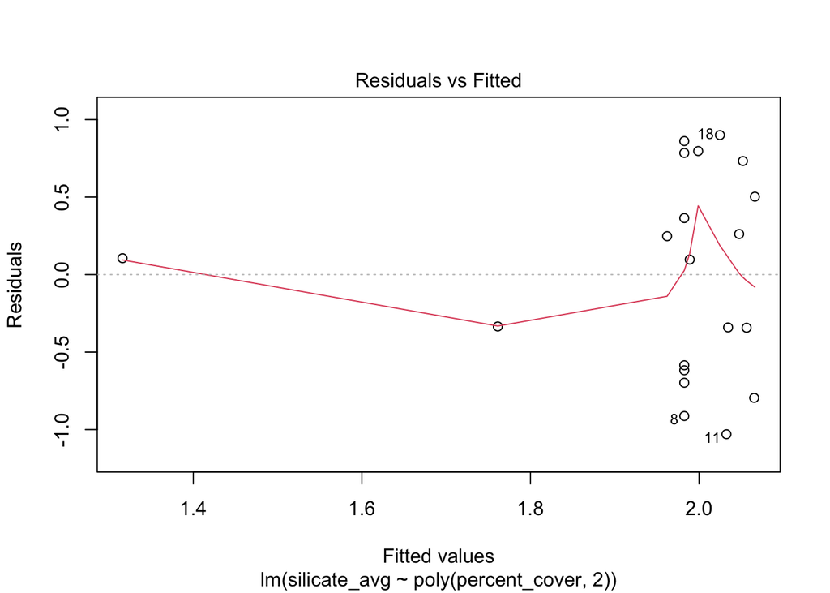

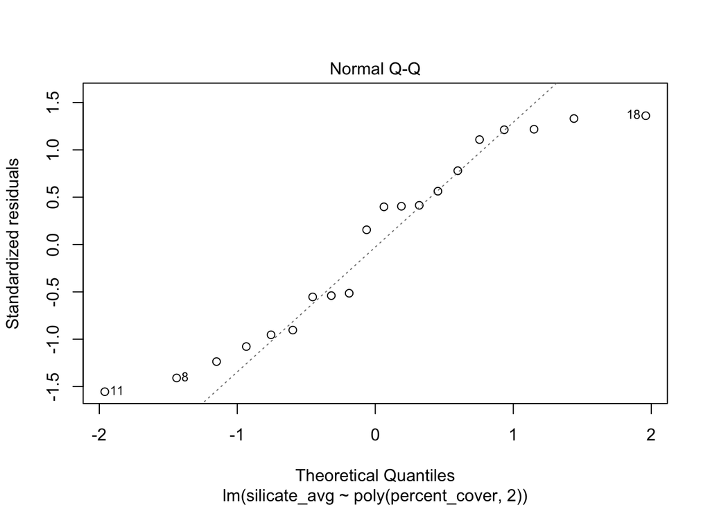

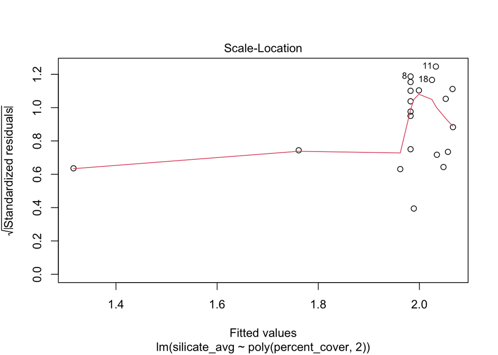

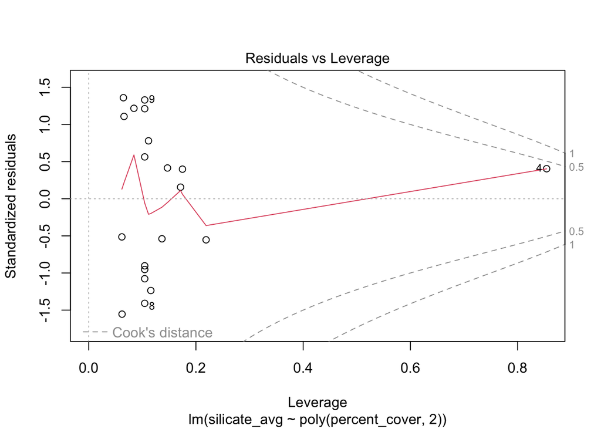

```r
##########################
## check residuals and plot normality
##########################

#### plot models
plot(PocCover_vs_Silicate_model_V)
```

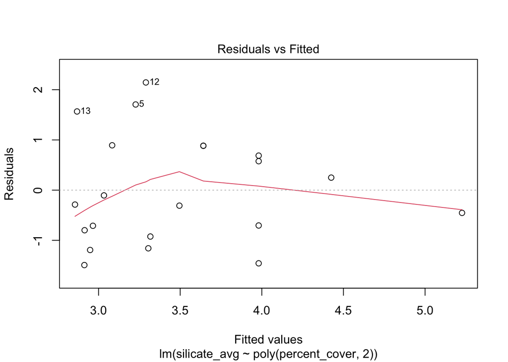

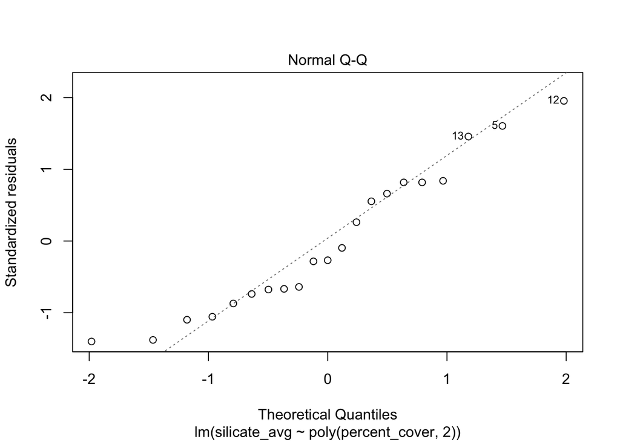

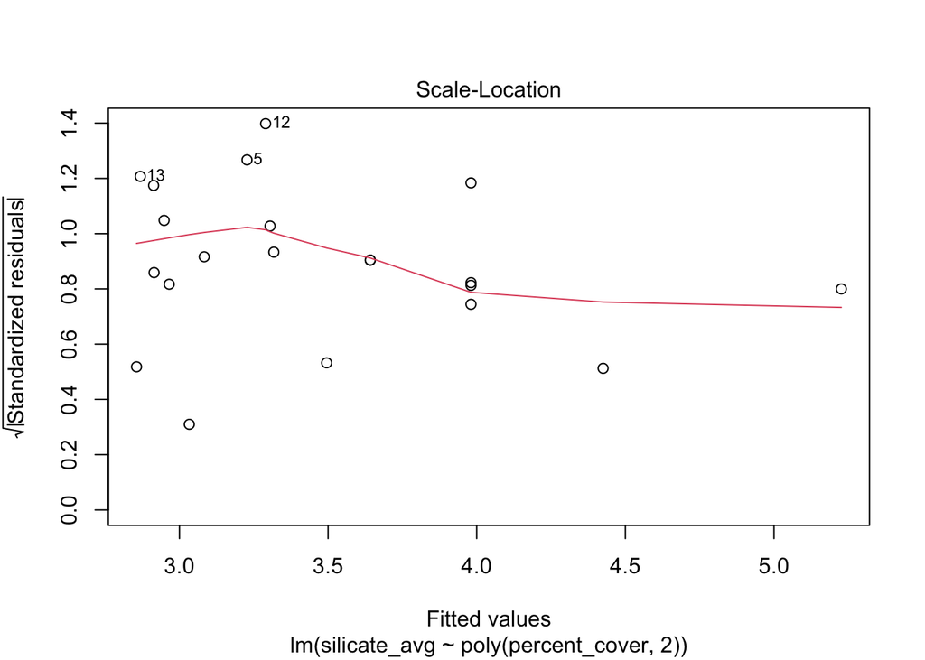

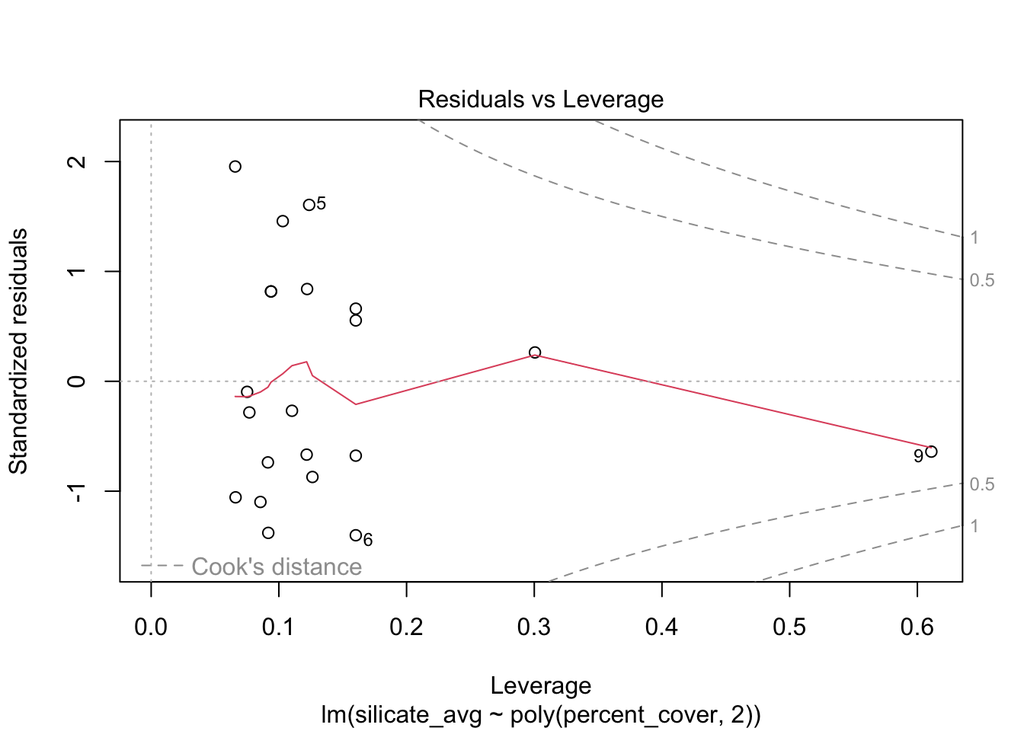

```r
plot(PocCover_vs_Silicate_model_C)
```

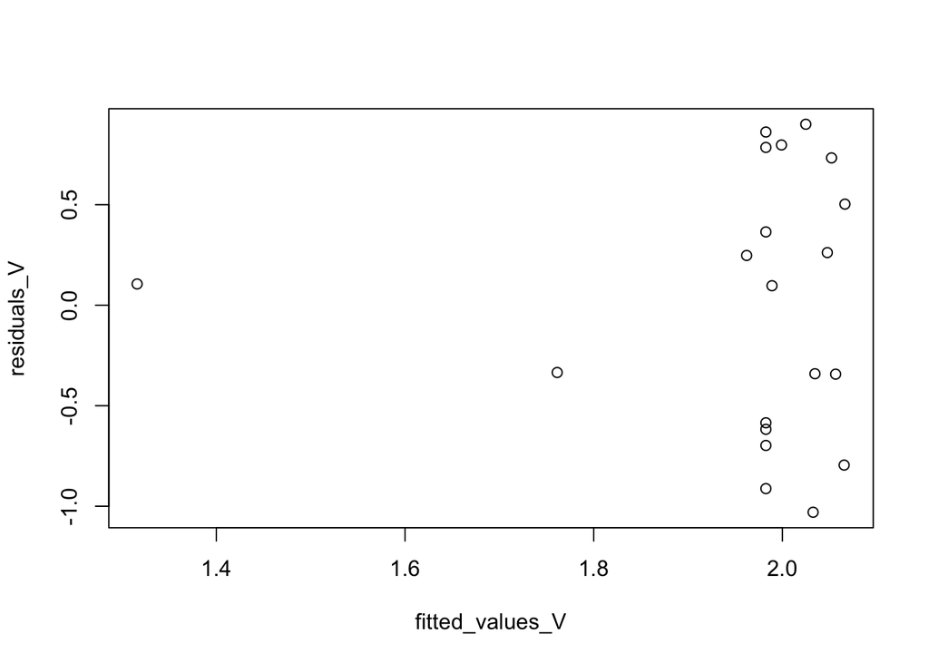

```r
#### look at residuals

## varai
residuals_V <- resid(PocCover_vs_Silicate_model_V)
fitted_values_V <- fitted(PocCover_vs_Silicate_model_V)

plot(fitted_values_V, residuals_V)
```

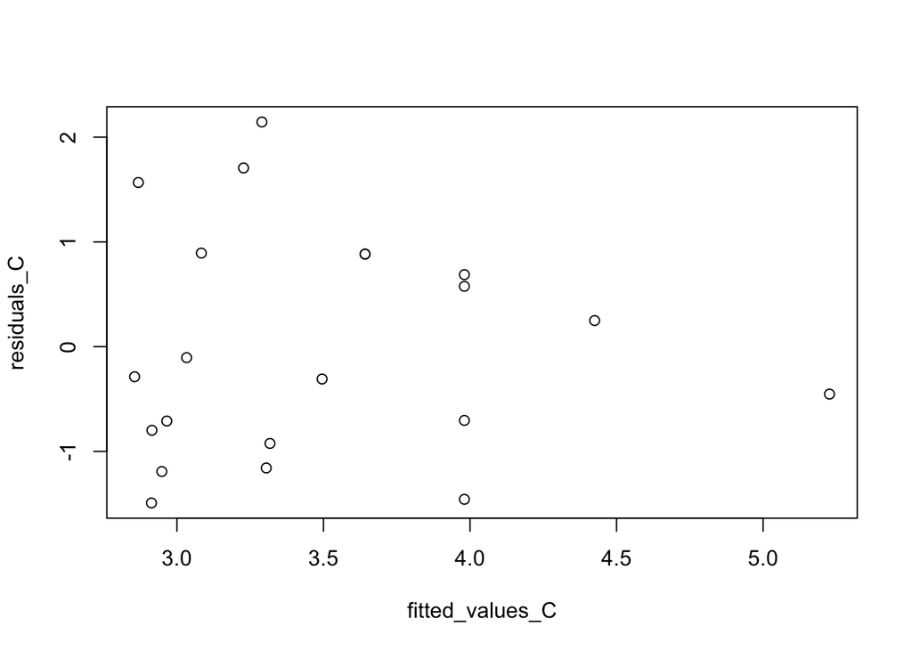

```r
## cabral
residuals_C <- resid(PocCover_vs_Silicate_model_C)
fitted_values_C <- fitted(PocCover_vs_Silicate_model_C)

plot(fitted_values_C, residuals_C)
```

### Run a t-test to compare Poc cover with settlement and show in a boxplot

- compare between Location so x-axis is Location and y axis is mean settlement OR mean Poc cover (separate analyses)
- edit df to create mean column
- **Results**: there is no significant difference in the means b/w sites for either settlement or Poc cover

```r
EnvData_wPocCover_ttest <- EnvData_wPocCover %>%
  select(!c("sum_total_dead":"total_count_biotics")) %>%
  group_by(Location) %>%
  mutate(log_settled = log(sum_total+1),
         sq_percentcover = sqrt(percent_cover)) %>%
  mutate(mean_settled = mean(log_settled),
         mean_cover = mean(sq_percentcover))

##### settlement
Settlement_Ttest<-t.test(log(sum_total+1)~Location, data=EnvData_wPocCover_ttest, na.rm=TRUE)

Settlement_Ttest
```

```
##
##  Welch Two Sample t-test
##
## data:  log(sum_total + 1) by Location
## t = -1.6829, df = 38.98, p-value = 0.1004
## alternative hypothesis: true difference in means between group Cabral and group Varari is not equal to 0
## 95 percent confidence interval:
##  -1.4249396  0.1306601
## sample estimates:
## mean in group Cabral mean in group Varari
##             2.300881             2.948021
```

```r
##### cover
PocCover_Ttest<-t.test(sq_percentcover~Location, data=EnvData_wPocCover_ttest, na.rm=TRUE)

PocCover_Ttest
```

```
##
##  Welch Two Sample t-test
##
## data:  sq_percentcover by Location
## t = -0.62899, df = 30.481, p-value = 0.534
## alternative hypothesis: true difference in means between group Cabral and group Varari is not equal to 0
## 95 percent confidence interval:
##  -1.1689005  0.6181487
## sample estimates:
## mean in group Cabral mean in group Varari
##             1.529554             1.804930
```

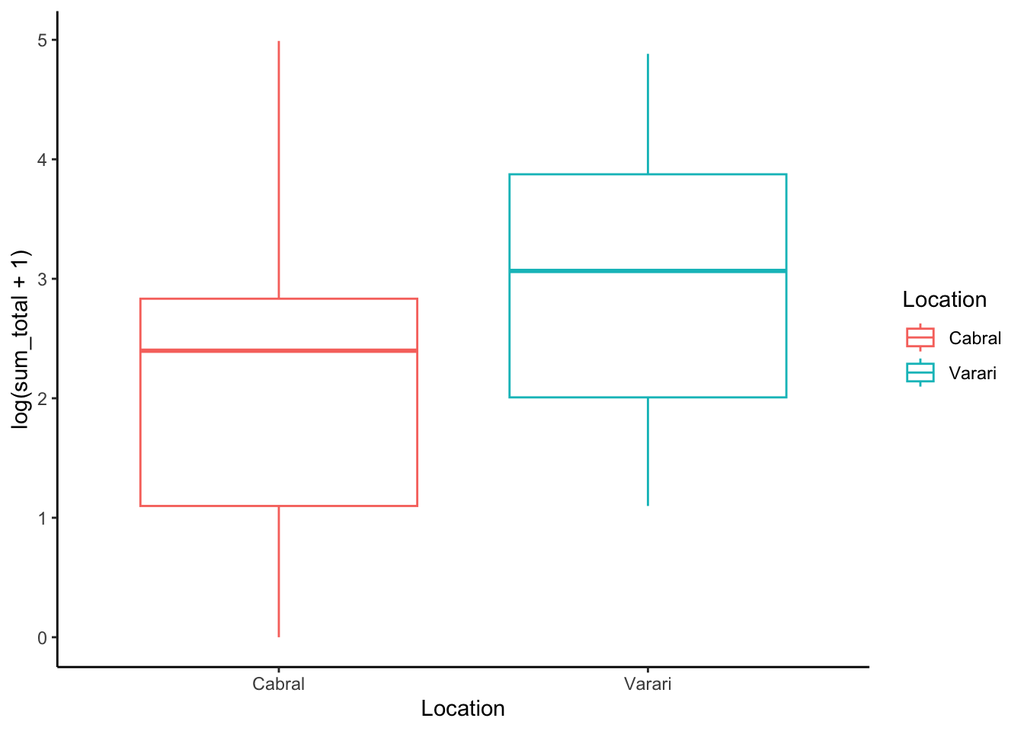

```r
##### boxplot
Settlement_boxplot <- EnvData_wPocCover_ttest %>%
  ggplot(aes(x=Location,
             y=log(sum_total+1),
             color=Location)) +
  geom_boxplot() +
  theme_classic()

Settlement_boxplot
```

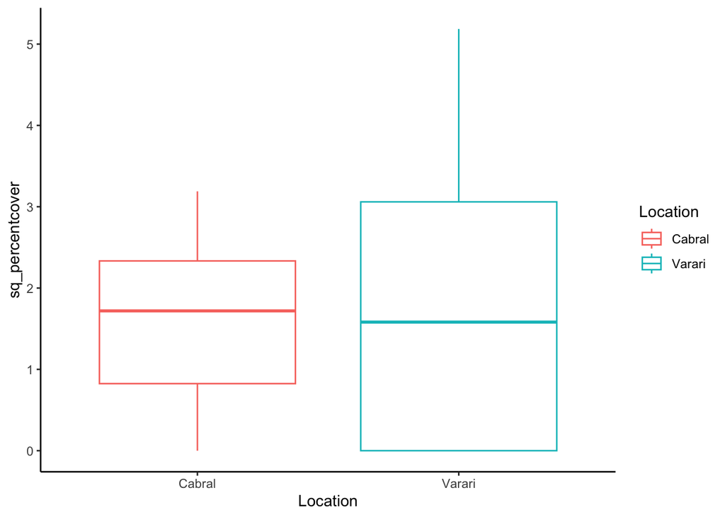

```r
PocCover_boxplot <- EnvData_wPocCover_ttest %>%
  ggplot(aes(x=Location,
             y=sq_percentcover,
             color=Location)) +
  geom_boxplot() +
  theme_classic()

PocCover_boxplot
```

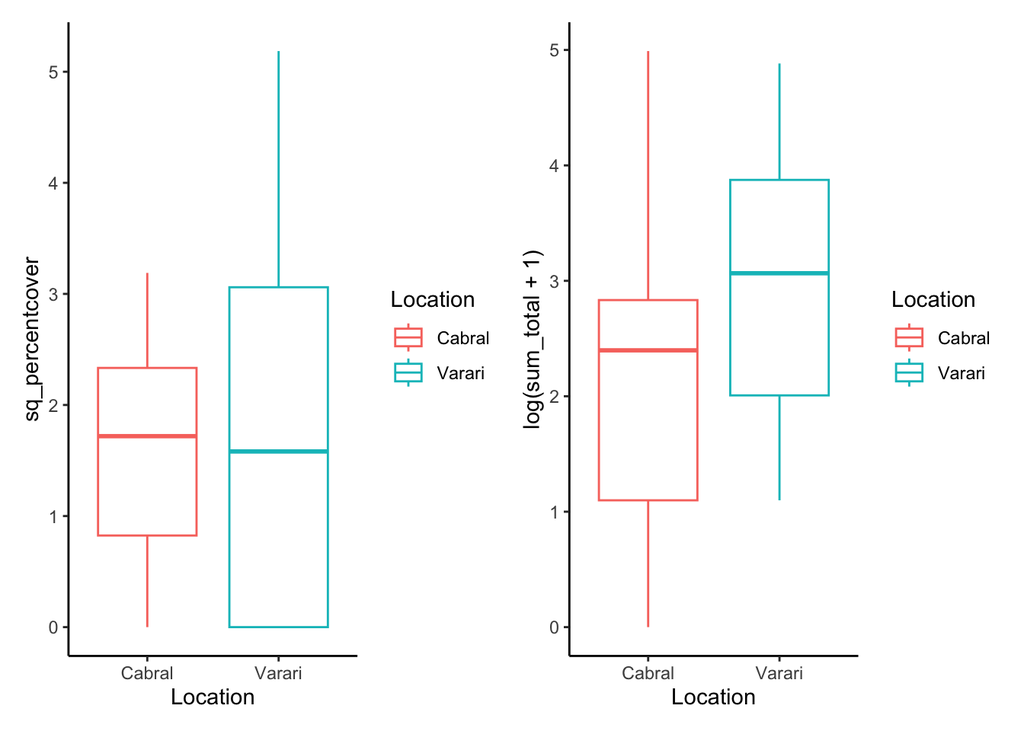

```r
##### patch together
PocCover_boxplot + Settlement_boxplot
```